# Chapter 5: Dimensionality reduction techniques

*Describe the work you have done this week and summarize your learning.*

```r
date()
```

```
## [1] "Mon Dec 06 05:11:08 2021"
```

```r
library(FactoMineR)
```

```r
library(tidyr)
library(ggplot2)
data("tea")
human <- read.csv(file = ".\\data\\human2.csv", header = TRUE)
```

### Task 1: Graphical overview of the dataset

```r
str(human)
```

```
## 'data.frame':    155 obs. of  9 variables:
##  $ X    : chr  "Norway" "Australia" "Switzerland" "Denmark" ...
##  $ edu2R: num  1.007 0.997 0.983 0.989 0.969 ...
##  $ labR : num  0.891 0.819 0.825 0.884 0.829 ...
##  $ life : num  81.6 82.4 83 80.2 81.6 80.9 80.9 79.1 82 81.8 ...
##  $ edu  : num  17.5 20.2 15.8 18.7 17.9 16.5 18.6 16.5 15.9 19.2 ...
##  $ gni  : int  64992 42261 56431 44025 45435 43919 39568 52947 42155 32689 ...
##  $ mmr  : int  4 6 6 5 6 7 9 28 11 8 ...
##  $ abr  : num  7.8 12.1 1.9 5.1 6.2 3.8 8.2 31 14.5 25.3 ...
##  $ parl : num  39.6 30.5 28.5 38 36.9 36.9 19.9 19.4 28.2 31.4 ...
```

The HDI was created to emphasize that people and their capabilities should be the ultimate criteria for assessing the development of a country, not economic growth alone. The HDI can also be used to question national policy choices, asking how two countries with the same level of GNI per capita can end up with different human development outcomes.

This data set is partial collection of dataset which calculated the HDI country by country. The human data set contains the following values:

- X: Header of each row. Every row is a data from a single country
- life: Life expectancy index
- gni: Gross National Income. Modified by removing comma from the income.
- labR: Female and male labour force participation rates
- edu2R: Female and male population with at least secondary education
- parl: Female and male shares of parliamentary seats
- mmr: Maternal Mortality ratio
- abr: Adolescent Birth Rate
- edu: Expected years of schooling

### Task 2: Perform principal component analysis

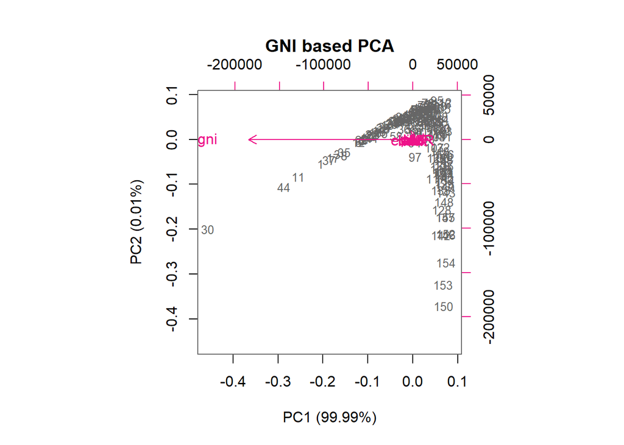

```r
pca_human <- prcomp(human[-1])
s <- summary(pca_human)
pca_pr <- round(100*s$importance[2, ], digits = 2)
pc_lab <- paste0(names(pca_pr), " (", pca_pr, "%)")
biplot(pca_human, choices = 1:2, cex = c(0.8, 1), col = c("grey40", "deeppink2"), xlab = pc_lab[1], ylab = pc_lab[2], main = "GNI based PCA")
```

### Task 3: Standardize the variables and repeat the above analysis

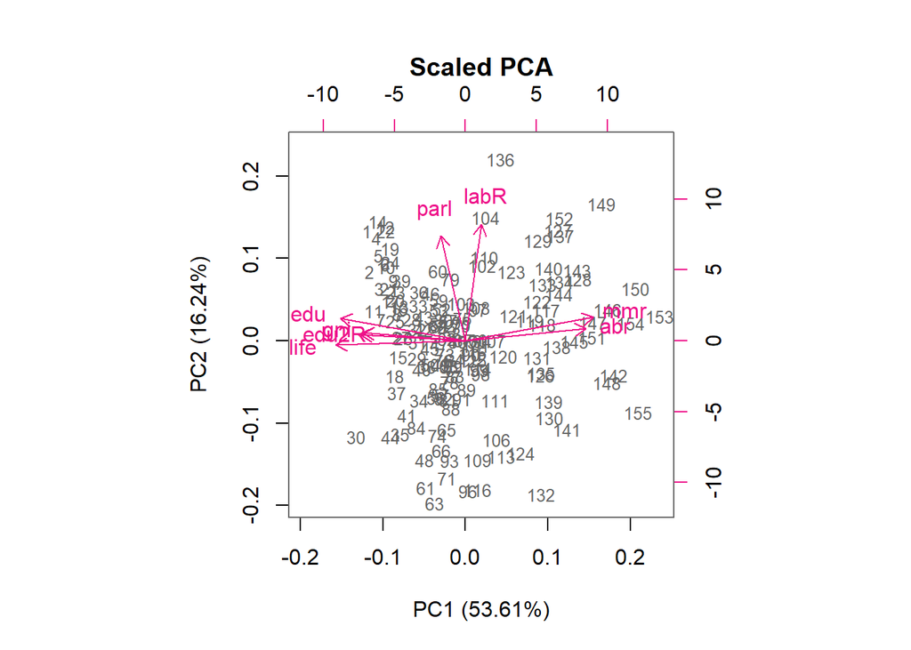

```r
pca_human <- prcomp(scale(human[-1]))
s <- summary(pca_human)
pca_pr <- round(100*s$importance[2, ], digits = 2)
pc_lab <- paste0(names(pca_pr), " (", pca_pr, "%)")
biplot(pca_human, choices = 1:2, cex = c(0.8, 1), col = c("grey40", "deeppink2"), xlab = pc_lab[1], ylab = pc_lab[2], main = "Scaled PCA")
```

When comparing standardized and not standardized biplot charts you can clearly see that the scaling is off. The values of the gni are really large, because at data mangling the comma was taken out and textual value was transferred into numberic. This changed the values into almost 100 000. Without scaling, these gni values are really big compared to other data so the biplot is really off. You can see from not standardized one that the only arrow is gni, and others are so small that they are not even drawn.

### Task 4: Personal interpretations, two principal component dimensions

Rest of the measured values are 53,6% of the reasons which affect the HDI. Maternal Mortal Ratio and Adolescent Birth Rate are on the positive side and it is getting better. On the other hand education and life expetancy and GNI are lacking behind. People die young and are not that educated.

### Task 5: Personal interpretations, two principal component dimensions

```r
str(tea)
```

```
## 'data.frame':    300 obs. of  36 variables:
##  $ breakfast       : Factor w/ 2 levels "breakfast","Not.breakfast": 1 1 2 2 1 2 1 2 1 1 ...
##  $ tea.time        : Factor w/ 2 levels "Not.tea time",..: 1 1 2 1 1 1 2 2 2 1 ...
##  $ evening         : Factor w/ 2 levels "evening","Not.evening": 2 2 1 2 1 2 2 1 2 1 ...
##  $ lunch           : Factor w/ 2 levels "lunch","Not.lunch": 2 2 2 2 2 2 2 2 2 2 ...
##  $ dinner          : Factor w/ 2 levels "dinner","Not.dinner": 2 2 1 1 2 1 2 2 2 2 ...
##  $ always          : Factor w/ 2 levels "always","Not.always": 2 2 2 2 1 2 2 2 2 2 ...
##  $ home            : Factor w/ 2 levels "home","Not.home": 1 1 1 1 1 1 1 1 1 1 ...
##  $ work            : Factor w/ 2 levels "Not.work","work": 1 1 2 1 1 1 1 1 1 1 ...
##  $ tearoom         : Factor w/ 2 levels "Not.tearoom",..: 1 1 1 1 1 1 1 1 1 2 ...
##  $ friends         : Factor w/ 2 levels "friends","Not.friends": 2 2 1 2 2 2 1 2 2 2 ...
##  $ resto           : Factor w/ 2 levels "Not.resto","resto": 1 1 2 1 1 1 1 1 1 1 ...
##  $ pub             : Factor w/ 2 levels "Not.pub","pub": 1 1 1 1 1 1 1 1 1 1 ...
##  $ Tea             : Factor w/ 3 levels "black","Earl Grey",..: 1 1 2 2 2 2 2 1 2 1 ...
##  $ How             : Factor w/ 4 levels "alone","lemon",..: 1 3 1 1 1 1 1 3 3 1 ...
```

[output cut: 22 more lines]

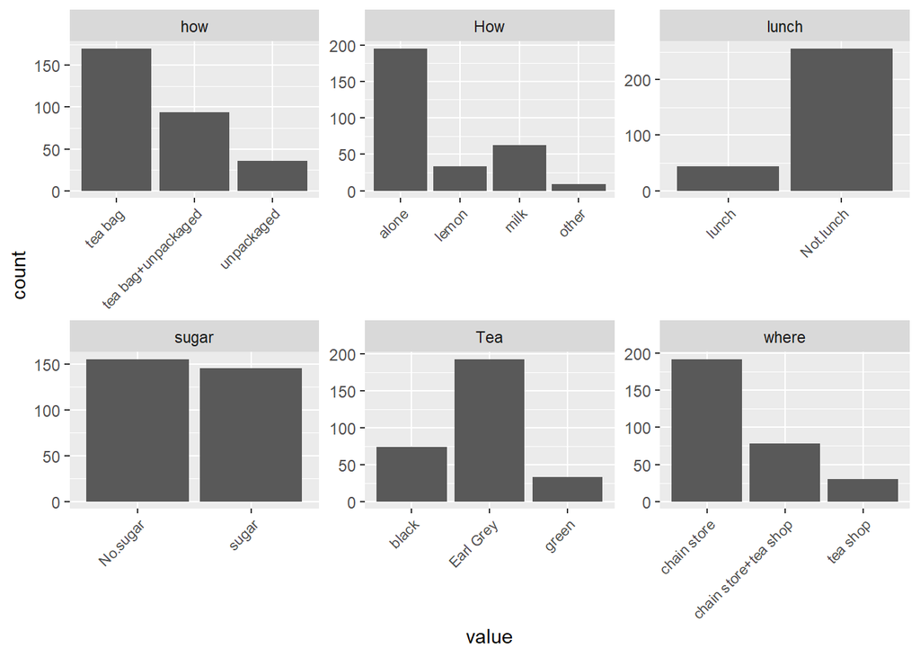

```r
keep_columns <- c("Tea", "How", "how", "sugar", "where", "lunch")
tea_time <- dplyr::select(tea, one_of(keep_columns))
tidyr::gather(tea_time) %>% ggplot(aes(value)) + facet_wrap("key", scales = "free") + geom_bar() + theme(axis.text.x = element_text(angle = 45, hjust = 1, size = 8))
```

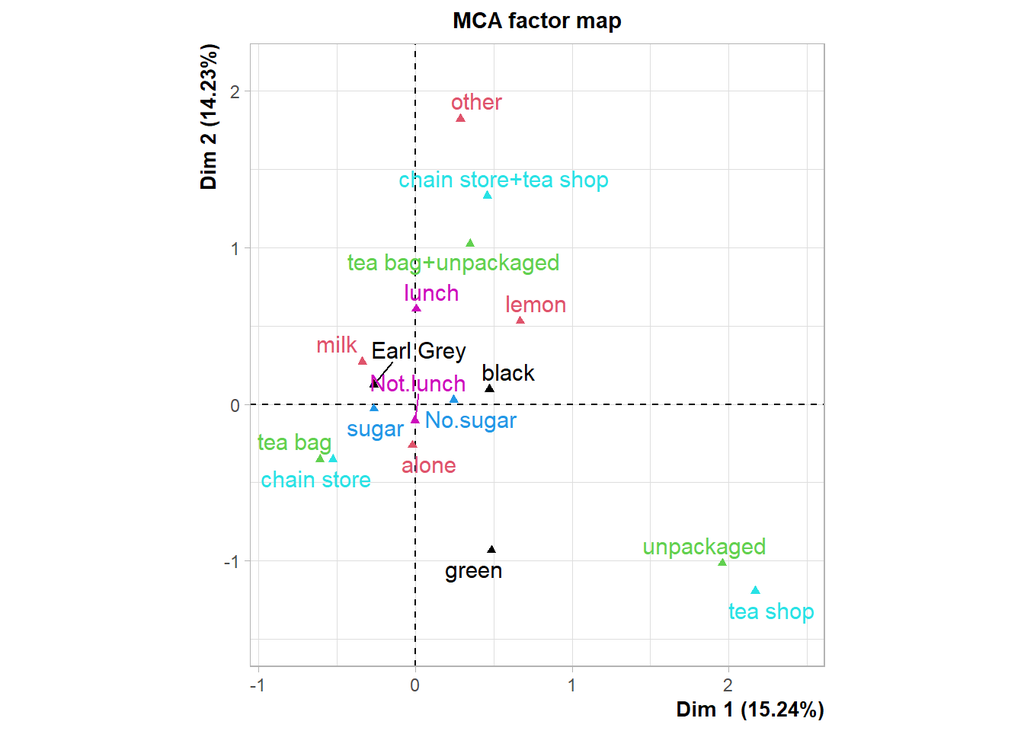

```r
mca <- MCA(tea_time, graph = FALSE)
plot(mca, invisible=c("ind"), habillage = "quali")
```

I chose a dataset which focused on the tea, which people are consumed. Are the bags or loose tea, with sugar or without, where bought, which type, at lunch, or do people consume tea with addition flavours like lemon or milk.